# Week 6 Rmarkdown

# Part 1 - Tokyo Olympics

## Is there a significant effect of a country’s GDP on their position in the Olympics?

### Installing packages and data

Installing tidyverse and vroom

Install the Tokyo Medals Data:

```r
Tokyo_Data <- vroom("https://raw.githubusercontent.com/chrit88/Bioinformatics_data/master/Workshop%205/Tokyo%202021%20medals.csv")
```

Install wbstats for access to the GDP data

install.packages(“wbstats”)

Renaming the column so it is nicer to look at and easier to understand

```r
my_indicators = c("GDP" = "NY.GDP.MKTP.CD")
```

Extract the GDP data for all countries

```r
GDP_Raw <- wb_data(my_indicators,
                    start_date = 2020,
                    end_date = 2020)
```

Having a look at the data

```r
GDP_Raw
```

```
## # A tibble: 217 x 9
##    iso2c iso3c country     date       GDP unit  obs_status footnote last_updated
##    <chr> <chr> <chr>      <dbl>     <dbl> <chr> <chr>      <chr>    <date>
##  1 AW    ABW   Aruba       2020  NA       <NA>  <NA>       <NA>     2021-12-16
##  2 AF    AFG   Afghanist~  2020   2.01e10 <NA>  <NA>       <NA>     2021-12-16
##  3 AO    AGO   Angola      2020   5.84e10 <NA>  <NA>       <NA>     2021-12-16
##  4 AL    ALB   Albania     2020   1.49e10 <NA>  <NA>       <NA>     2021-12-16
##  5 AD    AND   Andorra     2020  NA       <NA>  <NA>       <NA>     2021-12-16
##  6 AE    ARE   United Ar~  2020   3.59e11 <NA>  <NA>       <NA>     2021-12-16
##  7 AR    ARG   Argentina   2020   3.89e11 <NA>  <NA>       <NA>     2021-12-16
##  8 AM    ARM   Armenia     2020   1.26e10 <NA>  <NA>       <NA>     2021-12-16
##  9 AS    ASM   American ~  2020   7.09e 8 <NA>  <NA>       <NA>     2021-12-16
## 10 AG    ATG   Antigua a~  2020   1.37e 9 <NA>  <NA>       <NA>     2021-12-16
## # ... with 207 more rows
```

### Making it neater

It seems as though there are some columns we won’t need, so let us get rid of those: Getting rid of useless columns from the data set:

```r
GDP_Data <- subset(GDP_Raw, select = c(1, 2, 3, 4, 5, 9))
# Have a look
GDP_Data
```

```
## # A tibble: 217 x 6
##    iso2c iso3c country               date           GDP last_updated
##    <chr> <chr> <chr>                <dbl>         <dbl> <date>
##  1 AW    ABW   Aruba                 2020           NA  2021-12-16
##  2 AF    AFG   Afghanistan           2020  20116137326. 2021-12-16
##  3 AO    AGO   Angola                2020  58375976293. 2021-12-16
##  4 AL    ALB   Albania               2020  14887629268. 2021-12-16
##  5 AD    AND   Andorra               2020           NA  2021-12-16
##  6 AE    ARE   United Arab Emirates  2020 358868765175. 2021-12-16
##  7 AR    ARG   Argentina             2020 389288056265. 2021-12-16
##  8 AM    ARM   Armenia               2020  12641209802. 2021-12-16
##  9 AS    ASM   American Samoa        2020    709000000  2021-12-16
## 10 AG    ATG   Antigua and Barbuda   2020   1370281481. 2021-12-16
## # ... with 207 more rows
```

```r
# Yay it worked!
```

## Joining the two data sets:

Now we need to join the so let’s rename one of the GDP_Data rows for the join:

```r
GDP_Data_Final<- rename(GDP_Data, code = iso3c)
```

Adding a column to Tokyo Data containing country code:

```r
library(countrycode)
```

Adding the iso3c column to the Tokyo Data enabling joining later on:

```r
Tokyo_Data$code <- countrycode(Tokyo_Data$Country,
                                  origin = "country.name",
                                  destination = "iso3c")
```

Giving China the CHN

```r
Tokyo_Data$code <- sub("TWN", "CHN", Tokyo_Data$code)
Tokyo_Data$code[42] <- "TWN"
```

Joining the data using inner join :

```r
GDP_And_Medals_Raw <- inner_join(Tokyo_Data, GDP_Data_Final, by = "code")
GDP_And_Medals_Raw
```

```
## # A tibble: 87 x 10
##    Country    Gold Silver Bronze code  iso2c country   date     GDP last_updated
##    <chr>     <dbl>  <dbl>  <dbl> <chr> <chr> <chr>    <dbl>   <dbl> <date>
##  1 United S~    39     41     33 USA   US    United ~  2020 2.09e13 2021-12-16
##  2 Republic~    38     32     18 CHN   CN    China     2020 1.47e13 2021-12-16
##  3 Japan        27     14     17 JPN   JP    Japan     2020 5.06e12 2021-12-16
##  4 Great Br~    22     21     22 GBR   GB    United ~  2020 2.76e12 2021-12-16
##  5 Russia       20     28     23 RUS   RU    Russian~  2020 1.48e12 2021-12-16
##  6 Australia    17      7     22 AUS   AU    Austral~  2020 1.33e12 2021-12-16
##  7 Germany      10     11     16 DEU   DE    Germany   2020 3.85e12 2021-12-16
##  8 Italy        10     10     20 ITA   IT    Italy     2020 1.89e12 2021-12-16
##  9 France       10     12     11 FRA   FR    France    2020 2.63e12 2021-12-16
## 10 Netherla~    10     12     14 NLD   NL    Netherl~  2020 9.14e11 2021-12-16
## # ... with 77 more rows
```

Looks good although we now have NA values too

Remove all of the NA values

```r
GDP_And_Medals_Final <- na.omit(GDP_And_Medals_Raw)
GDP_And_Medals_Final
```

```
## # A tibble: 83 x 10
##    Country    Gold Silver Bronze code  iso2c country   date     GDP last_updated
##    <chr>     <dbl>  <dbl>  <dbl> <chr> <chr> <chr>    <dbl>   <dbl> <date>
##  1 United S~    39     41     33 USA   US    United ~  2020 2.09e13 2021-12-16
##  2 Republic~    38     32     18 CHN   CN    China     2020 1.47e13 2021-12-16
##  3 Japan        27     14     17 JPN   JP    Japan     2020 5.06e12 2021-12-16
##  4 Great Br~    22     21     22 GBR   GB    United ~  2020 2.76e12 2021-12-16
##  5 Russia       20     28     23 RUS   RU    Russian~  2020 1.48e12 2021-12-16
##  6 Australia    17      7     22 AUS   AU    Austral~  2020 1.33e12 2021-12-16
##  7 Germany      10     11     16 DEU   DE    Germany   2020 3.85e12 2021-12-16
##  8 Italy        10     10     20 ITA   IT    Italy     2020 1.89e12 2021-12-16
##  9 France       10     12     11 FRA   FR    France    2020 2.63e12 2021-12-16
## 10 Netherla~    10     12     14 NLD   NL    Netherl~  2020 9.14e11 2021-12-16
## # ... with 73 more rows
```

Ordering the data set based on how the olympic medal table ranking works:

```r
GDP_And_Medals_Final <-GDP_And_Medals_Final[order(-GDP_And_Medals_Final$Gold, -GDP_And_Medals_Final$Silver, -GDP_And_Medals_Final$Bronze),]
```

Using the index to give the countries a Rank:

```r
GDP_And_Medals_Final <- tibble::rowid_to_column(GDP_And_Medals_Final, "Rank")
```

### Getting ready to plot

install the ggplot2 package

```r
install.packages("ggplot2")
# Use the ggplot 2 library
library(ggplot2)
```

## Plotting

Investigating an initial plot of medal ranking and GDP:

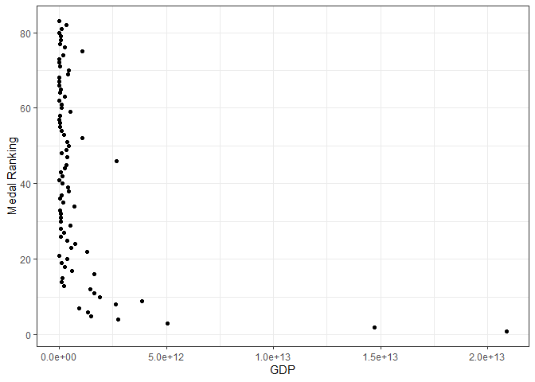

It looks okay but could do with some logging perhaps of the GDP to make things more clear.

Pseudo logging the GDP and adding a geom_smooth line

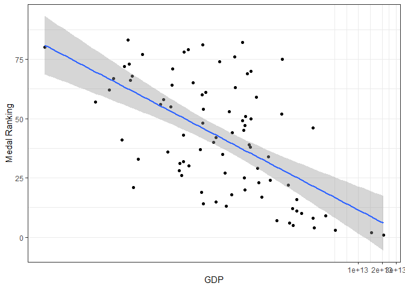

```r
p2 <- p1 +
  scale_x_continuous(trans="pseudo_log") +
    geom_smooth(method="glm")
```

It looks okay!

## Assessing the fit of a model:

Mod 1 is going to be the “Gaussian” or normally distributed:

```r
mod1 <- glm(Rank ~ GDP,
                data = GDP_And_Medals_Final,
                family = "gaussian")
```

Mod 2 is going to be the “poisson” type:

```r
mod2 <- glm(Rank ~ GDP,
            data = GDP_And_Medals_Final,
            family = "poisson")
```

Mod 3 is the Gaussian with the link being log:

```r
mod3 <- glm(Rank ~ GDP,
            data = GDP_And_Medals_Final,
            family = gaussian(link="log"))
```

Mod 4 is the Gaussian link with inverse link:

```r
mod4 <- glm(Rank ~ GDP,
            data = GDP_And_Medals_Final,
            family = gaussian(link = "inverse"))
```

Getting library gamlr

```r
library(gamlr)
```

Comparing the models:

```r
AIC_mods <- AIC(mod1,
                mod2,
                mod3,
                mod4)
```

Rank them by AIC using the order() function

```r
AIC_mods[order(AIC_mods$AIC),]
```

```
##      df       AIC
## mod4  3  731.4183
## mod3  3  731.5383
## mod1  3  754.2027
## mod2  2 1242.2560
```

It looks as though model 4, the gaussian, link = inverse, is slightly better so lets check that out:

## Investigating our model further:

Now looking at mod4 Create column of log predicted Gaussian

```r
GDP_And_Medals_Final$pred_gaussian_log <- predict(mod4,
                                        type = "response")
```

Plotting the diagnostics plot for model 4

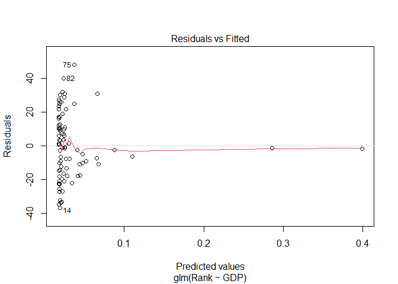

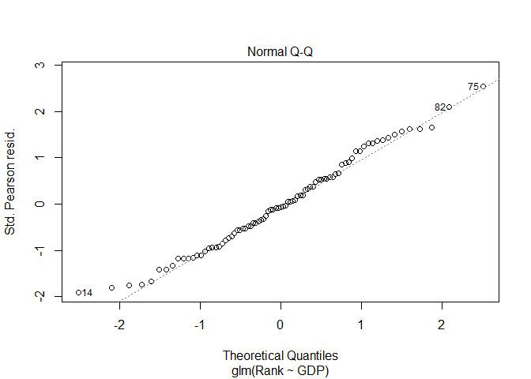

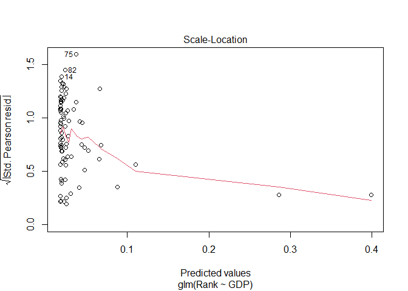

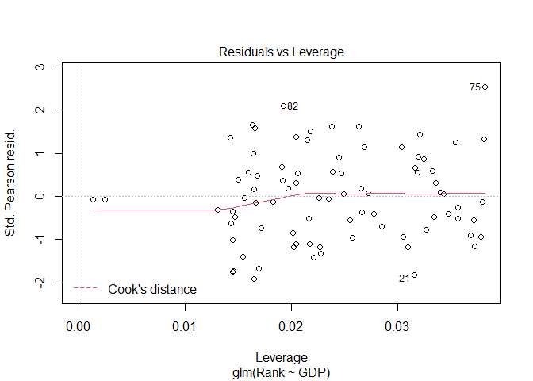

Creating a column for residual Gaussian log

```r
GDP_And_Medals_Final$resid_gaussian_log <- resid(mod4)
```

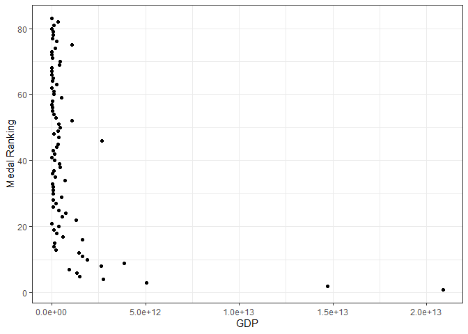

Applying the model to the plot (method = glm)

[figure not shown]

```r
p3 <-  p3 +
  scale_x_continuous(trans="log") +
  geom_smooth(method="glm") +
  xlab("Medal Ranking") +
  ylab("log_GDP") +
  ggtitle( " Logged GDP Data")

p3
```

I thought this was a good model. There is no residuals plotted but the data points are clear.

Now having a look at the model summary:

```r
summary(mod3)
```

```
##
## Call:
## glm(formula = Rank ~ GDP, family = gaussian(link = "log"), data = GDP_And_Medals_Final)
##
## Deviance Residuals:
##     Min       1Q   Median       3Q      Max
## -36.866  -14.805    0.904   12.977   47.710
##
## Coefficients:
##               Estimate Std. Error t value Pr(>|t|)
## (Intercept)  3.998e+00  5.766e-02  69.340  < 2e-16 ***
## GDP         -6.442e-13  1.680e-13  -3.835 0.000247 ***
## ---
## Signif. codes:  0 '***' 0.001 '**' 0.01 '*' 0.05 '.' 0.1 ' ' 1
##
## (Dispersion parameter for gaussian family taken to be 375.3847)
##
##     Null deviance: 47642  on 82  degrees of freedom
## Residual deviance: 30406  on 81  degrees of freedom
## AIC: 731.54
##
## Number of Fisher Scoring iterations: 7
```

## This was the solution that you gave which I have adapted to my data:

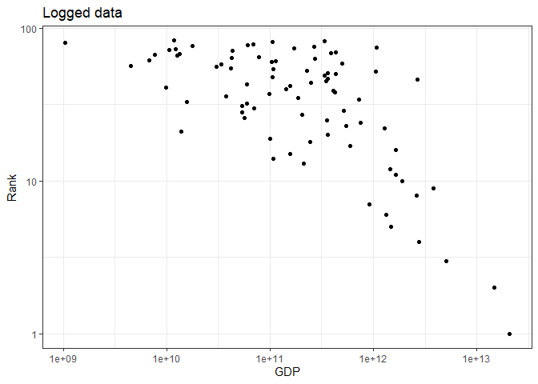

Fit a model where neither the x or y are logged:

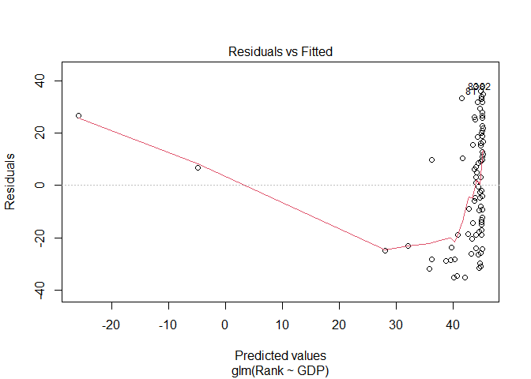

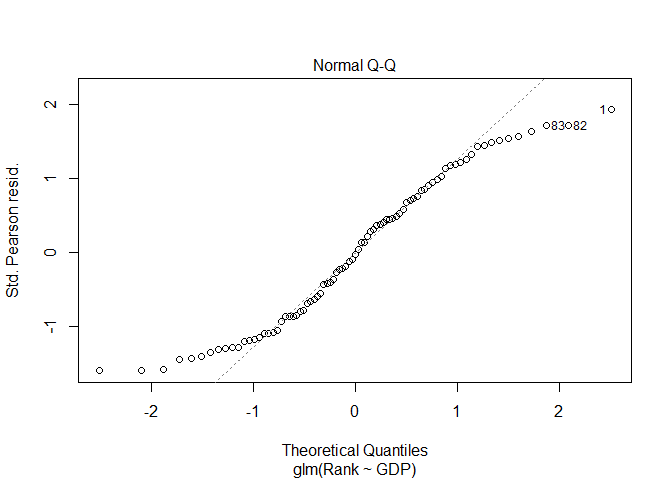

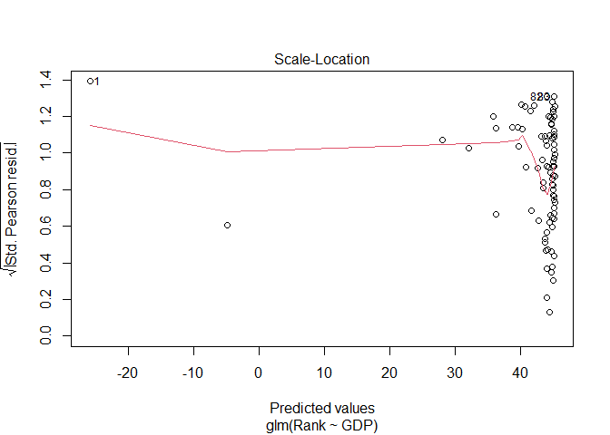

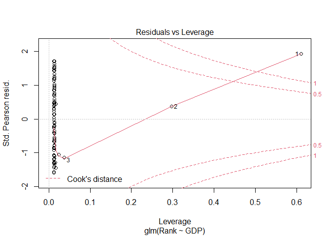

```r
mod6 <- glm(Rank ~ GDP, data=GDP_And_Medals_Final)
plot(mod6)
```

DOESNT LOOK GOOD!

Fit a model where both the x and y are logged:

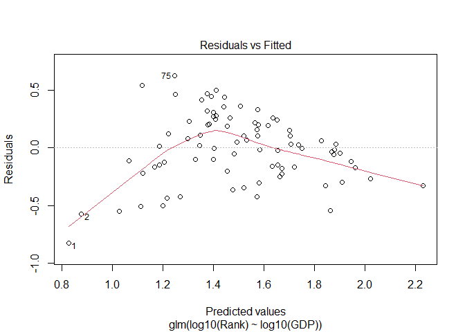

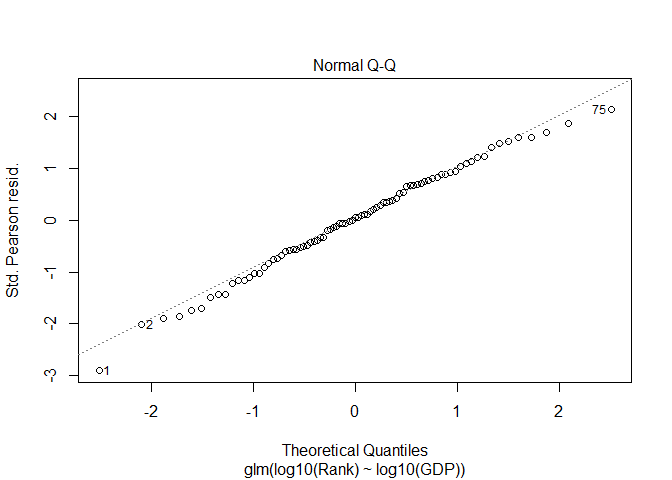

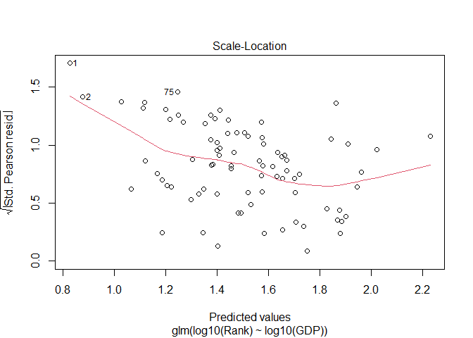

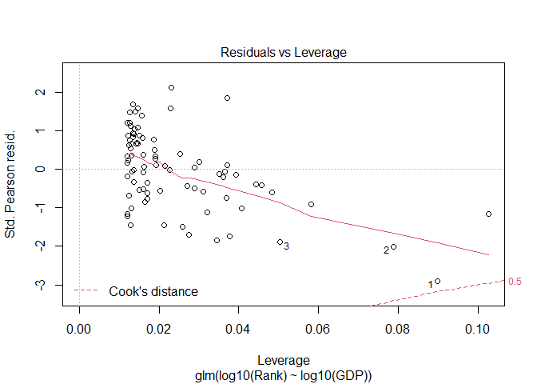

```r
mod7 <- glm(log10(Rank) ~ log10(GDP), data=GDP_And_Medals_Final)
plot(mod7)
```

So, is there an effect?

```r
summary(mod7)
```

```
##
## Call:
## glm(formula = log10(Rank) ~ log10(GDP), data = GDP_And_Medals_Final)
##
## Deviance Residuals:
##      Min        1Q    Median        3Q       Max
## -0.82625  -0.17531   0.01719   0.21434   0.62833
##
## Coefficients:
##             Estimate Std. Error t value Pr(>|t|)
## (Intercept)  5.17119    0.45305  11.414  < 2e-16 ***
## log10(GDP)  -0.32620    0.04016  -8.122 4.32e-12 ***
## ---
## Signif. codes:  0 '***' 0.001 '**' 0.01 '*' 0.05 '.' 0.1 ' ' 1
##
## (Dispersion parameter for gaussian family taken to be 0.0888732)
##
##     Null deviance: 13.0614  on 82  degrees of freedom
## Residual deviance:  7.1987  on 81  degrees of freedom
## AIC: 38.614
##
## Number of Fisher Scoring iterations: 2
```

# Part 2 - Iris

## Is there a positive effect of Petal.Length on Petal.Width?

```r
data("iris")
library(ggplot2)
```

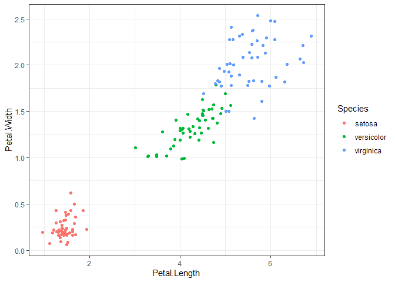

Petal length and petal width histograms:

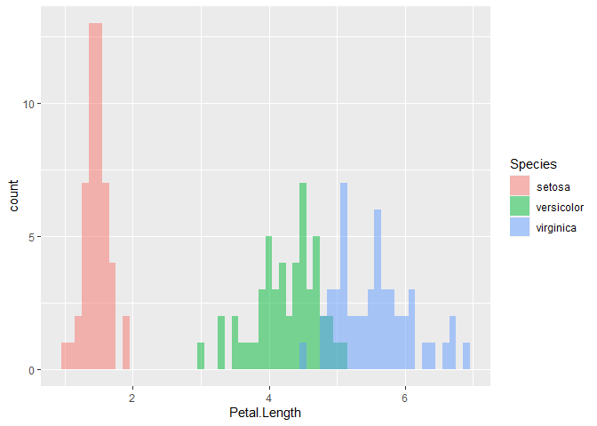

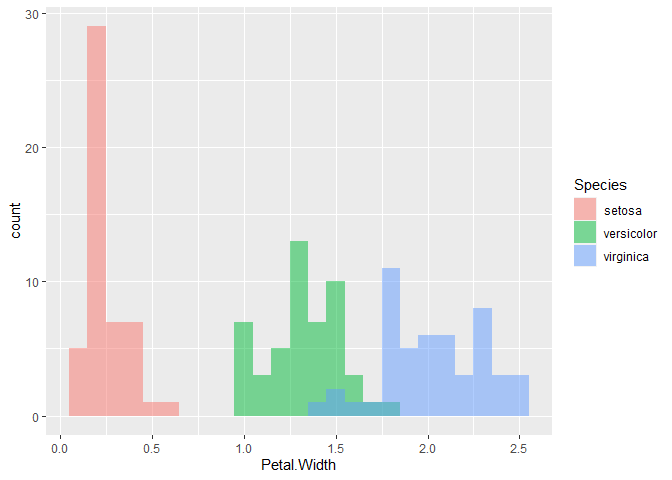

```r
# 1. Petal Length Histogram
a <- ggplot(iris, aes(x=Petal.Length,
                  fill=Species)) +
  geom_histogram(binwidth=.1, alpha=.5, position = "identity")

# 2.Petal Width Histogram

b <- ggplot(iris, aes(x=Petal.Width,
                 fill=Species)) +
  geom_histogram(binwidth=.1, alpha=.5, position = "identity")
```

Generate and plot the model:

Investigating the model:

```r
class(mod1)
```

```
## [1] "glm" "lm"
```

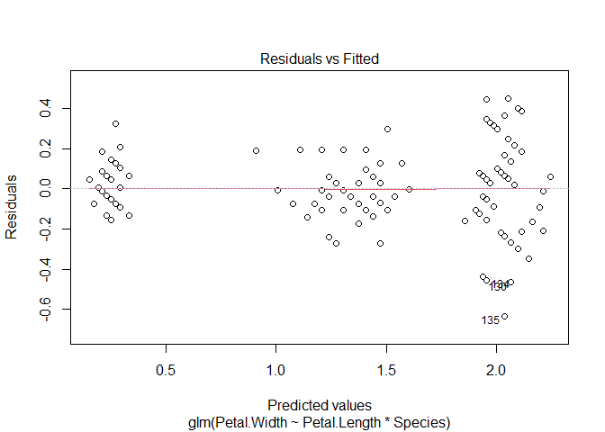

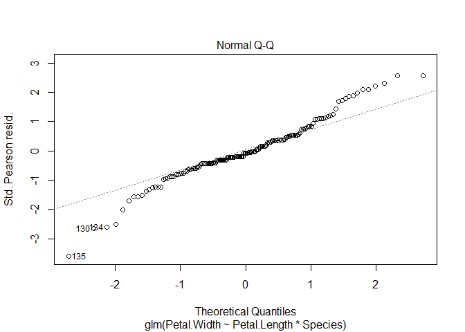

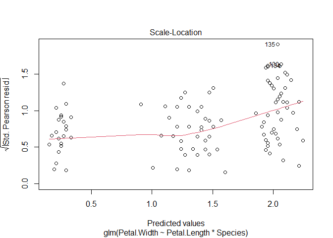

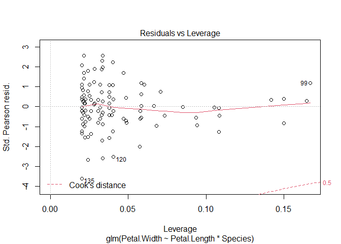

```r
plot(mod1)
```

```r
summary(mod1)
```

```
##
## Call:
## glm(formula = Petal.Width ~ Petal.Length * Species, family = "gaussian",
##     data = iris)
##
## Deviance Residuals:
##     Min       1Q   Median       3Q      Max
## -0.6337  -0.0744  -0.0134   0.0866   0.4503
##
## Coefficients:
##                                Estimate Std. Error t value Pr(>|t|)
## (Intercept)                    -0.04822    0.21472  -0.225 0.822627
## Petal.Length                    0.20125    0.14586   1.380 0.169813
## Speciesversicolor              -0.03607    0.31538  -0.114 0.909109
## Speciesvirginica                1.18425    0.33417   3.544 0.000532 ***
## Petal.Length:Speciesversicolor  0.12981    0.15550   0.835 0.405230
## Petal.Length:Speciesvirginica  -0.04095    0.15291  -0.268 0.789244
## ---
## Signif. codes:  0 '***' 0.001 '**' 0.01 '*' 0.05 '.' 0.1 ' ' 1
##
## (Dispersion parameter for gaussian family taken to be 0.03144043)
##
##     Null deviance: 86.5699  on 149  degrees of freedom
## Residual deviance:  4.5274  on 144  degrees of freedom
## AIC: -85.391
##
## Number of Fisher Scoring iterations: 2
```

Generating 3 other models:

[output not shown]

[output cut: 218 more lines]

[output not shown]

Comparing the models using the Akaike’s Information Criterion (AIC)

Ranking them them by AIC using the order() function

```r
AIC_mods[order(AIC_mods$AICc),]
```

```
##   model      AICc
## 2  mod2 -84.80660
## 1  mod1 -84.60212
## 4  mod4 -84.38363
## 3  mod3       Inf
```

Returning the predicted gaussian and residual gaussian and adding them as columns:

```r
# predicted gaussian:
iris$pred_gaussian <- predict(mod1,
                                    type="response")

# returning the residual gaussian:
iris$resid_gaussian <- resid(mod1)
```

## Making a plot

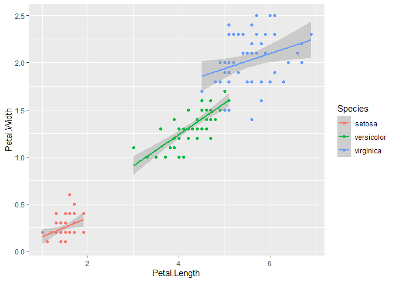

## Starting Again:

Data vizualisation:

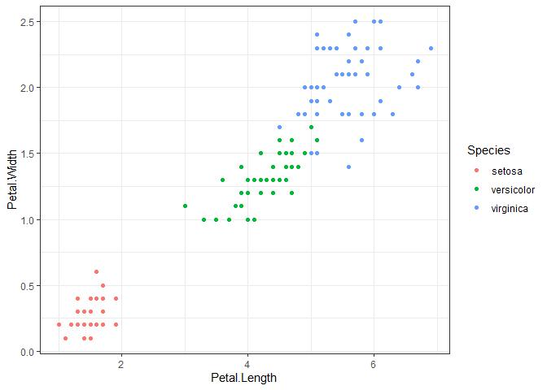

```r
iris1 <- ggplot(iris, aes(x = Petal.Length, y = Petal.Width)) +
  geom_point(aes(col = Species)) +
  theme_bw()

iris1
```

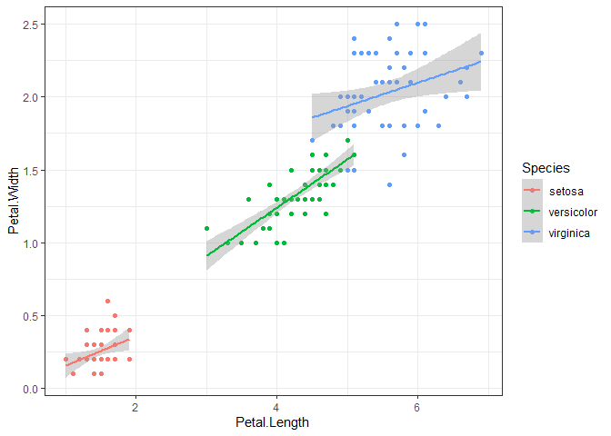

```r
iris1 + geom_smooth(aes(col = Species), method="lm")
```

Running model one

The qqplot looks a bit uneven

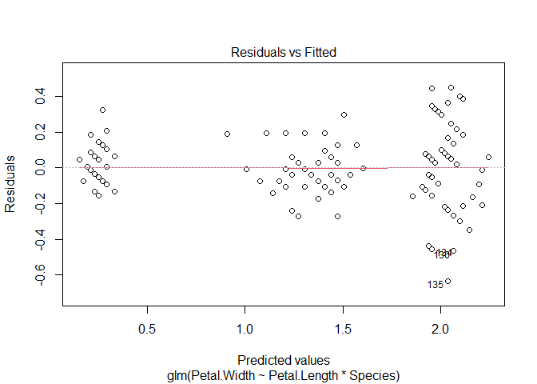

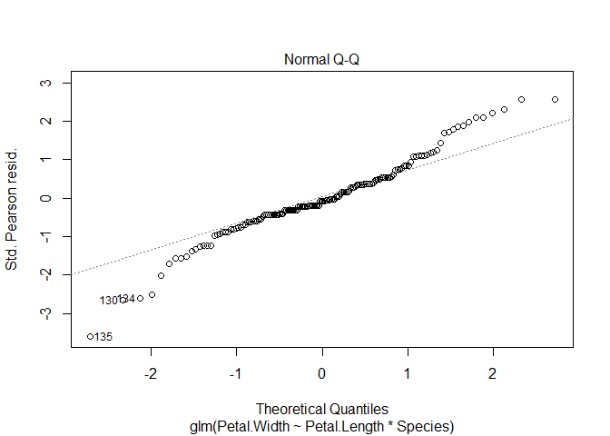

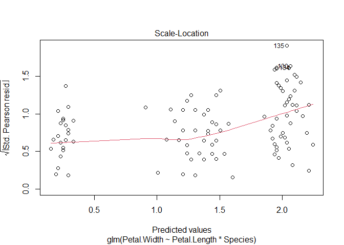

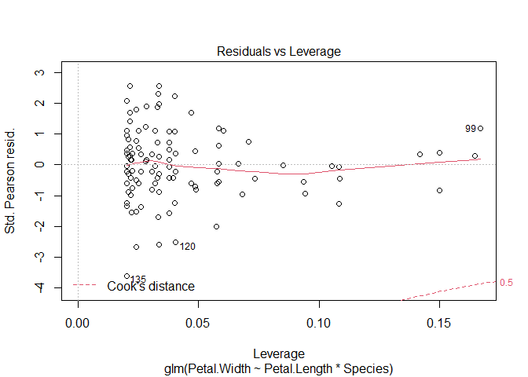

What about square root?